# Ist die DOI für ein Matching von Publikationsdatenbanken ausreichend?

Sitzung der KB Konsortialpartner  
26. November 2021

## Hintergrund

- Kombination unterschiedlicher Publikationsdatenbanken erfordert Matching
- Möglichkeit: Identifier nutzen, z.B. DOI
- Problematik: Fehlende oder falsch hinterlegte Identifier in mindestens einer der Datenbanken
- Lösung(sansatz): Weitere Felder für Zuordnung nutzen, etwa Titel der Publikation oder Metadaten der Zeitschrift
- Hier: Matching von WoS-KB (wos_b_2019) und Unpaywall (Snapshot von April 2019)
- Analysen und Bericht sind frei verfügbar in einem Github repositorium: https://github.com/nicholasmfraser/wos_unpaywall_matching

## Hintergrund: DOI-Information nach Jahr

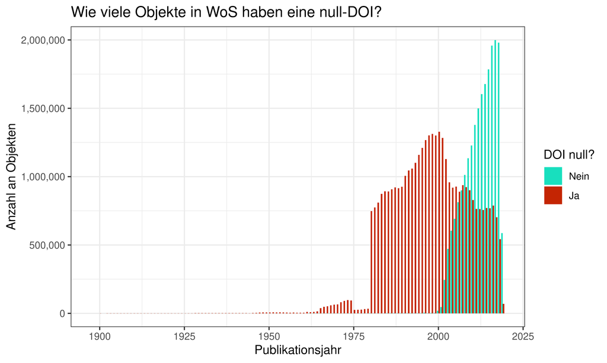

Insgesamt: etwa 36.1 % mit DOI, vor 2000: 0.26 %, ab 2000: 56.07 %

## Hintergrund: DOI-Information nach Artikeltyp

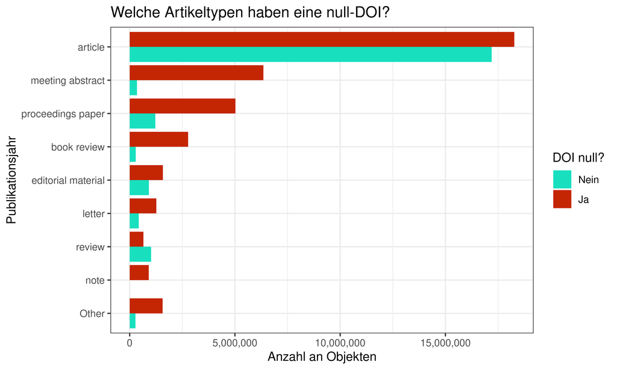

## Datenauswahl

Unpaywall:

- Snapshot von April 2019
- Publikationsjahr: 2014
- Artikeltyp (‘genre’): ‘journal-article’
- Datenzugriff über Google BigQuery Instanz der SUB Göttingen

Web of Science:

- Instanz des Kompetenzzentrums Bibliometrie
- Bibliometrische Datenbank ‘wos_b_2019’

Nutzung von `LOWER` and `TRIM`

## Kandidaten für Matching-Kriterien

Auf Ebene der Publikation:

- Publikationsjahr
- Titel der Publikation
- Anzahl der Autor*innen

Auf Ebene der Zeitschrift:

- Titel der Zeitschrift
- ISSN der Zeitschrift

## Kriterien: Publikationsjahr

| Unterschiede in Publikationsjahren | Anteil an gematchten Artikeln (in %) |
| --- | --- |
| Publikationsjahr in WoS früher als in Unpaywall | 0 |
| Identisches Publikationsjahr | 85 |
| Publikationsjahr in WoS ein Jahr später als in Unpaywall | 14 |
| Publikationsjahr in WoS zwei Jahre später als in Unpaywall | 1 |
| Publikationsjahr in WoS mehr als zwei Jahre später als in Unpaywall | 0 |

## Kriterien: Titel der Publikation, Ähnlichkeitsmaß

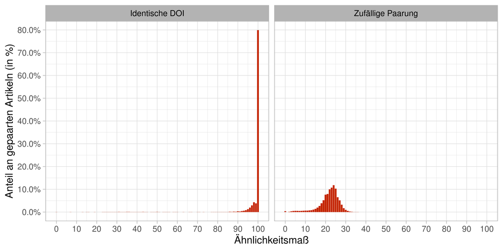

Basierend auf [Levenshtein Distanz](https://en.wikipedia.org/wiki/Levenshtein_distance), da [Jaro-Winkler Distanz](https://en.wikipedia.org/wiki/Jaro-Winkler_distance) geringere Trennschärfe aufweist

## Kriterien: Titel der Publikation, Titellänge

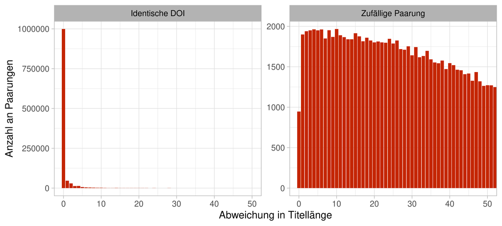

- Abweichung in der Titellänge von maximal 10 Zeichen: 97.57% der gematchten Artikel
- Reduktion der nötigen Vergleiche um 86.61%

## Kriterien: Titel der Publikation, Duplikate

- Eindeutigkeit von Artikeltiteln: 99.57% in WoS, 95.19% in Unpaywall
- Duplikate etwa ‘editorial’, ‘table of contents’, ‘front cover’, ‘issue information’, ‘untitled’, ‘introduction’
- Verwandte Dokumente: etwa ‘Corrigendum: [Originaltitel]’ oder ‘Addendum: [Originaltitel]’
- Vorgehensweise: Ausschluss von Duplikaten und anhand einer Schlüsselwortliste

## Kriterien: Autor*inneninformation

Kein Vergleich von Autor*innennamen aus folgenden Gründen:

- Problematik der Autor*innendisambiguierung
- Ineffizienz (Stringvergleiche)

Stattdessen: Anzahl der Autor*innen

## Kriterien: Zeitschrifteninformation

### Titel der Zeitschrift

- Abdeckung: 100% in WoS, 100% in Unpaywall mit Zeitschriftentitel
- Übereinstimmung bei DOI-gematchten Artikeln: 80.46%
- Unterschiede: durch Zeichenkodierung bzw. Abkürzungen

### ISSN

- Abdeckung: 99.28% in WoS, 99.95% in Unpaywall mit ISSN-Information
- Übereinstimmung bei DOI-gematchten Artikeln: 97.43%

## Matching Algorithmus

- Zunächst: DOI
- Anschließend: Zuordnung von Artikeltiteln (Ähnlichkeitsmaß der Levenshtein Distanz größer als 80 %)
- Auswahl von Kandidaten für Titelvergleich:
  - Publikationsjahr: identisch oder bis zu zwei Jahre später in WoS
  - Anzahl der Autor*innen: identisch
  - Titellänge: maximale Abweichung von 10 Zeichen
  - Zeitschrifteninformation: identische ISSN ODER identischer Titel

## Evaluation: Algorithmus unter Nutzung von DOI-Information

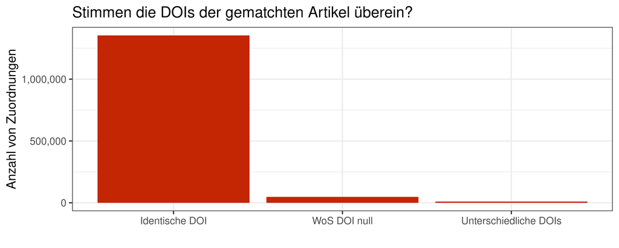

- Insgesamt: 1,410,995 Zuordnungen
- Überprüfung von 100 zufälligen Zuordnungen ohne WoS DOI: alle Unpaywall-DOIs korrekt

## Evaluation: Mehrfachzuordnungen

Einige Unpaywallartikel mit mehreren WoS Objekten gematcht

- Identische DOI für unterschiedliche PK_ITEMS und Titel in WoS
- Fast identische Einträge, Unterscheidung lediglich durch ein Wort oder eine Zahl (‘part 1’ und ‘part 2’)

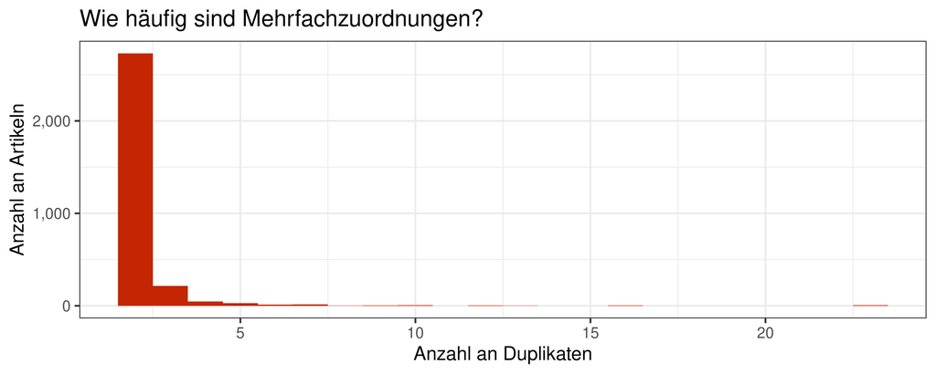

## Evaluation: Algorithmus OHNE vorhergehende DOI-Zuordnung

Referenz: Zuordnungen auf Basis der DOI (Ausschluss von Artikeln mit null DOI)

Wie viele Artikel werden gefunden (Recall)?

**94.78 %**

Wie viele gefundene Artikel sind korrekt zugeordnet (Präzision)?

**99.24 %.**

## Zusammenfassung und Diskussion

- Vielversprechende Ergebnisse
  - Hohe Anzahl an Matches, zusätzliche Funde auch bei hoher DOI-Abdeckung
  - Sehr geringer Anteil von Fehlzuordnungen
- Schwächen
  - Artikel mit sehr ähnlichen Titeln, identischer Autor*innenzahl im selben Journal
  - Nur eindeutige Titel berücksichtigt
  - Keine Evaluation der Zuverlässigkeit der Autor*innenanzahl
- Laufzeit: etwa 4 Stunden auf dem Skriptserver (mit DOI-Information etwas schneller)
- Mögliche Anpassungen und Lösungsansätze:
  - Höherer Schwellenwert für das Ähnlichkeitsmaß
  - Einarbeitung weiterer Kriterien (wie beispielsweise Autor*innennamen/-affiliationen)
  - Ausschluss nur von Artikeln, die in allen Kriterien übereinstimmen, oder Wahl eines Repräsentanten
  - Erstellung einer Matchingtabelle (einmaliges Durchlaufen)